# Final Project Team 12

For the distribution of different covariates, we observe that our data are relatively heterogeneous in terms of the distribution of different covariates. However, since we are using panel data, the fixed effects model is effective in controlling for individual heterogeneity that does not vary over time. Therefore, we do not need to use matching methods (e.g., PSM or IPW) because the fixed effects already absorb the effects of these time-invariant covariates. In addition, matching methods may lead to missing samples, which reduces estimation efficiency and does not deal with time-varying features. Therefore, we use a double difference (DiD) approach that combines State Fixed Effects and Year Fixed Effects to ensure that our estimates are not affected by initial covariate inhomogeneity.

```r
data <- data %>%
  mutate(across(all_of(crime_vars), ~ log(. + 1), .names = "log_{.col}"))

head(data)
```

| state | year | sid | cdl | pre2_cdl | caselaw | anywhere | assumption | civil | homicide_c | robbery_gun_r | jhcitizen_c | jhpolice_c | homicide | robbery | assault | burglary | larceny | motor | murder | hc_felonywsus | jhcitizen | jhpolice | population | police | unemployrt | income | blackm_15_24 | whitem_15_24 | blackm_25_44 | … |
| --- | --- | --- | --- | --- | --- | --- | --- | --- | --- | --- | --- | --- | --- | --- | --- | --- | --- | --- | --- | --- | --- | --- | --- | --- | --- | --- | --- | --- | --- | --- |
| Alabama | 2000 | 1 | 0 | 0 | 0 | 0 | 0 | 0 | 329 | 0.2108032 | 1 | 0 | 7.593978 | 131.6136 | 325.6178 | 930.9202 | 2940.624 | 295.6573 | 6.532207 | 0.4847220 | 0.04616400 | 0.02308200 | 4332380 | 348.8383 | 4.1 | 44851 | 2.222243 | 4.694810 | 3.471694 | … |
| Alabama | 2001 | 1 | 0 | 0 | 0 | 0 | 0 | 0 | 379 | 0.2143625 | 2 | 0 | 8.713443 | 128.3796 | 281.6350 | 934.3846 | 2758.690 | 290.1186 | 7.494940 | 0.6667278 | 0.06897184 | 0.02299061 | 4349601 | 351.8254 | 4.7 | 43301 | 2.249954 | 4.700201 | 3.440247 | … |
| Alabama | 2002 | 1 | 0 | 0 | 0 | 0 | 0 | 0 | 303 | 0.4240188 | 3 | 2 | 6.933288 | 136.4233 | 274.6314 | 974.2757 | 2835.829 | 317.8329 | 6.406999 | 0.5949356 | 0.09152855 | 0.06864642 | 4370221 | 311.4945 | 5.4 | 45573 | 2.258261 | 4.685461 | 3.403993 | … |
| Alabama | 2003 | 1 | 0 | 0 | 0 | 0 | 0 | 0 | 299 | 0.2454455 | 2 | 1 | 6.818007 | 137.6827 | 258.5370 | 986.1027 | 2828.424 | 341.0599 | 6.567177 | 0.3192378 | 0.06840809 | 0.04560539 | 4385446 | 348.5620 | 5.5 | 44165 | 2.292948 | 4.688166 | 3.383214 | … |
| Alabama | 2004 | 1 | 0 | 1 | 0 | 0 | 0 | 0 | 254 | 0.2610063 | 3 | 0 | 5.753689 | 136.8653 | 255.6541 | 1011.7885 | 2800.959 | 317.6761 | 5.595123 | 0.2265232 | 0.09060928 | 0.02265232 | 4414559 | 327.9150 | 5.1 | 42280 | 2.291327 | 4.661734 | 3.358841 | … |
| Alabama | 2005 | 1 | 0 | 1 | 0 | 0 | 0 | 0 | 374 | 0.1873740 | 0 | 1 | 8.418573 | 145.1191 | 254.2004 | 978.5579 | 2718.704 | 295.7755 | 6.932943 | 0.5627388 | 0.02250955 | 0.04501911 | 4442558 | 287.8072 | 3.9 | 41491 | 2.312046 | 4.635865 | 3.357210 | … |

Now let’s see the scatter plot of log-transformed data.

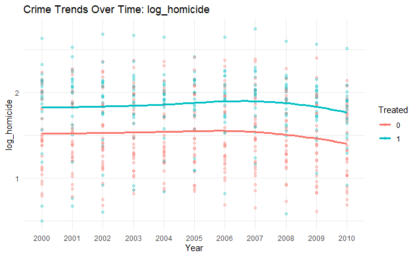

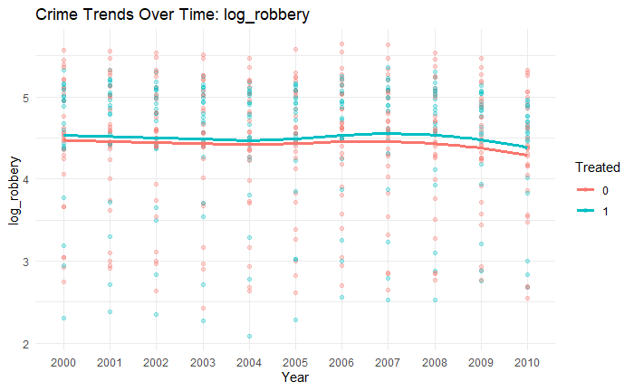

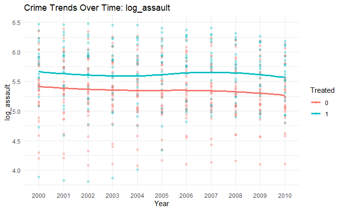

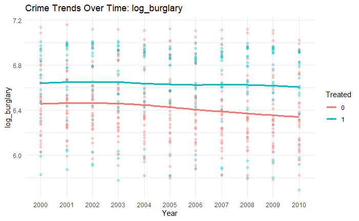

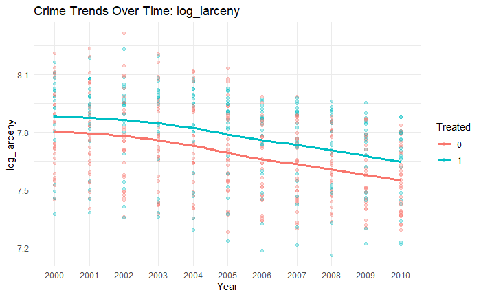

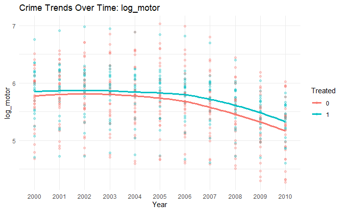

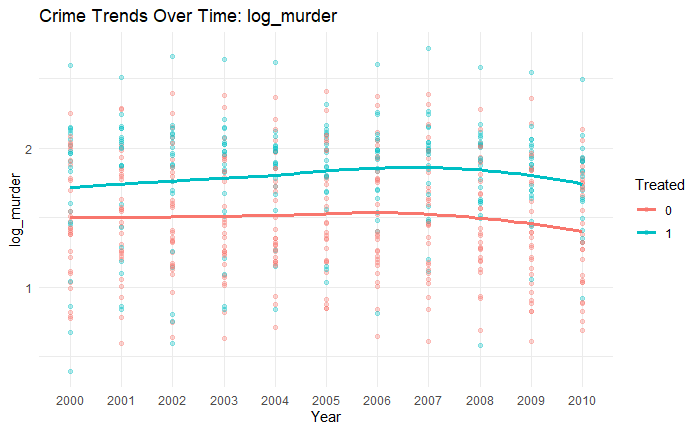

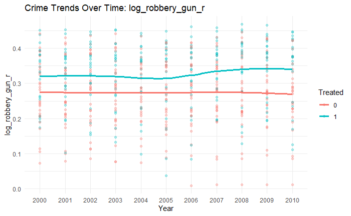

```r
crime_log_vars <- c("log_homicide", "log_robbery", "log_assault", "log_burglary", "log_larceny", "log_motor", "log_murder","log_robbery_gun_r")

for (var in crime_log_vars) {
  p1 <- ggplot(data, aes(x = year, y = .data[[var]], group = state, color = as.factor(treated))) +
    geom_point(alpha = 0.3) +
    geom_smooth(aes(group = treated), method = "loess", se = FALSE, size = 1.2) +
   # facet_wrap(~ treated) +
    labs(
      title = paste("Crime Trends Over Time:", var),
      x = "Year",
      y = var,
      color = "Treated"
    ) +
    theme_minimal()

  print(p1)
}
```

[figure not shown]

```r
par(mfrow = c(1,2))
hist(data$homicide, main = "Original Homicide", col = "steelblue")
hist(data$log_homicide, main = "Log Transformed Homicide", col = "skyblue")
```

We find that many of the variables have relatively much more even distributions after treatment.

### IV Setup

We found data on Rand on guns in each US state during the experimental year, and we thought the variables inside could provide us with instrumental variable possibilities. Specific conjectures and validation of the validity of the instrumental variables are presented later. The instrumental variables we use are:

- GunsAmmo: Within-year standardization of the square root of Guns and Ammo Subscriptions/Population
- HuntLic: Square root of Hunting Licenses/Population.

Our initial guess is that these two variables do not directly affect homicide and are related to legislation.

```r
firearm_data <- read.csv("State_Firearm_Data.csv", stringsAsFactors = FALSE)

colnames(firearm_data)[colnames(firearm_data) == "STATE"] <- "state"
colnames(firearm_data)[colnames(firearm_data) == "Year"] <- "year"

merged_data <- merge(data, firearm_data[, c("state", "year", "HFR","HuntLic","Fem_FS_S","Male_FS_S","GunsAmmo")],
                     by = c("state", "year"), all.x = TRUE)
head(merged_data)
```

|  | state | year | sid | cdl | pre2_cdl | caselaw | anywhere | assumption | civil | homicide_c | robbery_gun_r | jhcitizen_c | jhpolice_c | homicide | robbery | assault | burglary | larceny | motor | murder | hc_felonywsus | jhcitizen | jhpolice | population | police | unemployrt | income | blackm_15_24 | whitem_15_24 | … |
| --- | --- | --- | --- | --- | --- | --- | --- | --- | --- | --- | --- | --- | --- | --- | --- | --- | --- | --- | --- | --- | --- | --- | --- | --- | --- | --- | --- | --- | --- | --- |
| 1 | Alabama | 2000 | 1 | 0 | 0 | 0 | 0 | 0 | 0 | 329 | 0.2108032 | 1 | 0 | 7.593978 | 131.6136 | 325.6178 | 930.9202 | 2940.624 | 295.6573 | 6.532207 | 0.4847220 | 0.04616400 | 0.02308200 | 4332380 | 348.8383 | 4.1 | 44851 | 2.222243 | 4.694810 | … |
| 2 | Alabama | 2001 | 1 | 0 | 0 | 0 | 0 | 0 | 0 | 379 | 0.2143625 | 2 | 0 | 8.713443 | 128.3796 | 281.6350 | 934.3846 | 2758.690 | 290.1186 | 7.494940 | 0.6667278 | 0.06897184 | 0.02299061 | 4349601 | 351.8254 | 4.7 | 43301 | 2.249954 | 4.700201 | … |
| 3 | Alabama | 2002 | 1 | 0 | 0 | 0 | 0 | 0 | 0 | 303 | 0.4240188 | 3 | 2 | 6.933288 | 136.4233 | 274.6314 | 974.2757 | 2835.829 | 317.8329 | 6.406999 | 0.5949356 | 0.09152855 | 0.06864642 | 4370221 | 311.4945 | 5.4 | 45573 | 2.258261 | 4.685461 | … |
| 4 | Alabama | 2003 | 1 | 0 | 0 | 0 | 0 | 0 | 0 | 299 | 0.2454455 | 2 | 1 | 6.818007 | 137.6827 | 258.5370 | 986.1027 | 2828.424 | 341.0599 | 6.567177 | 0.3192378 | 0.06840809 | 0.04560539 | 4385446 | 348.5620 | 5.5 | 44165 | 2.292948 | 4.688166 | … |
| 5 | Alabama | 2004 | 1 | 0 | 1 | 0 | 0 | 0 | 0 | 254 | 0.2610063 | 3 | 0 | 5.753689 | 136.8653 | 255.6541 | 1011.7885 | 2800.959 | 317.6761 | 5.595123 | 0.2265232 | 0.09060928 | 0.02265232 | 4414559 | 327.9150 | 5.1 | 42280 | 2.291327 | 4.661734 | … |
| 6 | Alabama | 2005 | 1 | 0 | 1 | 0 | 0 | 0 | 0 | 374 | 0.1873740 | 0 | 1 | 8.418573 | 145.1191 | 254.2004 | 978.5579 | 2718.704 | 295.7755 | 6.932943 | 0.5627388 | 0.02250955 | 0.04501911 | 4442558 | 287.8072 | 3.9 | 41491 | 2.312046 | 4.635865 | … |

# Nationwide DiD/Fixed Effect Exploration

In the next section, we’ll analyze how the passage of the Castle Doctrine Law (CDL) impacted homicide nationwide. Our dataset is panel data that records different characteristics for each year in each state. We find that the year in which the law was introduced varies from state to state, so we take a DiD/fixed effects approach to this panel data to explore treatment effects. The parallel trend assumption can be confirmed by the previous chart called Crime Trends Over Time: Homicide. Therefore, we can continue.

```r
data.panel <- pdata.frame(merged_data, index = c("state", "year"))
pdim(data.panel)
```

```
Balanced Panel: n = 50, T = 11, N = 550
```

There are a total of 50 states (n = 50), the observation years are 2000-2010 (T = 11), and the total sample size, N = 550, is Balanced Panel data (BP).

```r
DiD.FE.StateYear <- plm(
  log_homicide ~ cdl,
  data  = data.panel,
  model = "within",
  effect = "twoways"
)

summary(DiD.FE.StateYear)
```

```
Twoways effects Within Model

Call:
plm(formula = log_homicide ~ cdl, data = data.panel, effect = "twoways",
    model = "within")

Balanced Panel: n = 50, T = 11, N = 550

Residuals:
       Min.     1st Qu.      Median     3rd Qu.        Max.
-0.52790922 -0.06573358 -0.00022851  0.06508375  0.48848116

Coefficients:
    Estimate Std. Error t-value Pr(>|t|)
cdl 0.056135   0.024649  2.2774   0.0232 *
---
Signif. codes:  0 ‘***’ 0.001 ‘**’ 0.01 ‘*’ 0.05 ‘.’ 0.1 ‘ ’ 1

Total Sum of Squares:    8.8507
Residual Sum of Squares: 8.7578
R-Squared:      0.010495
Adj. R-Squared: -0.11092
F-statistic: 5.18636 on 1 and 489 DF, p-value: 0.023196
```

This model used DiD + fixed effects (FE) to assess the impact of Castle Doctrine Law (CDL) on homicide rates. The model controls for time-invariant heterogeneity across states using State Fixed Effects and for national time trends using Year Fixed Effects to improve the reliability of causal identification.

The regression results show that the implementation of castle laws is positively associated with an increase in homicide rates. After controlling for time and area fixed effects, the implementation of castle laws resulted in an increase in homicide rates of approximately 5.6% (p = 0.023), a result that was significant at the 5% level. The positive effect of the coefficient suggests that castle laws may have failed to achieve their intended goal of deterring crime and instead may have contributed to more violent conflicts escalating into fatalities. This finding is consistent with some of the research that suggests that lowering the legal costs of using lethal force may lead to higher homicide rates.

In addition, the low R² of the model (0.01049) suggests that changes in the homicide rate are mainly influenced by factors that are not included, such as economic conditions, police investment, and gun ownership. Therefore, future studies can include more control variables to further verify the robustness of the policy effects. Heterogeneity analyses can also be conducted to explore the differences in the impact of the policy in different regions or populations.

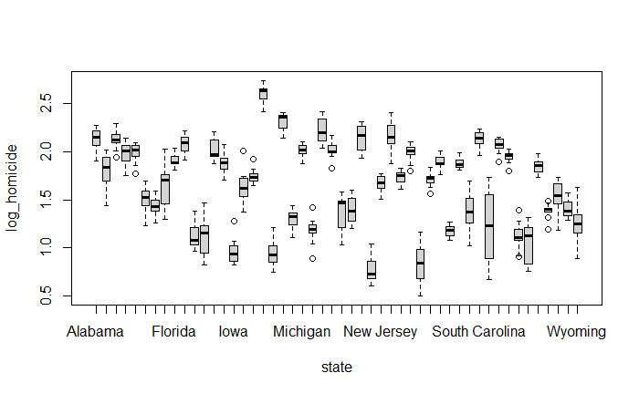

```r
boxplot(log_homicide~state, data = data.panel)
```

There is a large amount of heterogeneity across states, with some states (e.g., Alabama, Florida) having higher homicide rates and some states (e.g., South Dakota, Wyoming) having lower homicide rates. This suggests differences in the crime environment across states, which necessitates the use of state fixed effects (State FE).

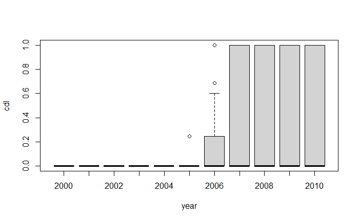

```r
boxplot(cdl~year, data = data.panel)
```

This validates the temporal variation in policy, i.e., states implemented the Castle Act in different years, providing strong support for the use of double-differencing (DiD).

Then, we are going to test if there is a need to use the state&year FE.

```r
DiD.Pooled<-lm(log_homicide ~ cdl, data = merged_data)
DiD.FE.State <- plm(log_homicide ~ cdl, data=data.panel,model="within")
```

```r
pFtest(DiD.FE.State,DiD.Pooled)
```

```
    F test for individual effects

data:  log_homicide ~ cdl
F = 101.94, df1 = 49, df2 = 499, p-value < 2.2e-16
alternative hypothesis: significant effects
```

- Unconstrained model (DiD.FE.State): contains state fixed effects (State FE).
- Constrained model (DiD.Pooled): plain OLS (no fixed effects included).
- Significance (p < 0.001) indicates that the fixed effects model outperforms the ordinary OLS.

This suggests that there is significant individual heterogeneity across states and that a simple OLS may be biased, thus state fixed effects (State FE) are necessary.

```r
pFtest(DiD.FE.StateYear,DiD.FE.State)
```

```
    F test for twoways effects

data:  log_homicide ~ cdl
F = 5.3093, df1 = 10, df2 = 489, p-value = 1.892e-07
alternative hypothesis: significant effects
```

- Unconstrained model (DiD.FE.StateYear): contains state fixed effects and year fixed effects (State FE + Year FE).
- Constrained model (DiD.FE.State): contains only state fixed effects (State FE).
- The p-value < 0.001 indicates that the inclusion of year fixed effects significantly improved the model fit.

This suggests that national time trends have a significant impact on homicide rates, such as national changes in economic conditions, policy environment, and law enforcement efforts, and thus year fixed effects (Year FE) are also necessary.

We try to use StateSpecific to further estimate the parallel trend hypothesis by adding the interaction term between Year and State.

```r
DiD.StateSpecific <- lm(log_homicide ~ cdl + factor(state) + factor(year) + factor(state)*(year), data=data)
summary(DiD.StateSpecific)
```

```
Call:
lm(formula = log_homicide ~ cdl + factor(state) + factor(year) +
    factor(state) * (year), data = data)

Residuals:
ALL 550 residuals are 0: no residual degrees of freedom!

Coefficients: (11 not defined because of singularities)
                                      Estimate Std. Error t value Pr(>|t|)
(Intercept)                           2.151062        NaN     NaN      NaN
cdl                                   0.119927        NaN     NaN      NaN
factor(state)Alaska                  -0.456578        NaN     NaN      NaN
factor(state)Arizona                 -0.053009        NaN     NaN      NaN
factor(state)Arkansas                -0.141131        NaN     NaN      NaN
factor(state)California              -0.164543        NaN     NaN      NaN
factor(state)Colorado                -0.717940        NaN     NaN      NaN
factor(state)Connecticut             -0.771834        NaN     NaN      NaN
factor(state)Delaware                -0.693905        NaN     NaN      NaN
factor(state)Florida                 -0.235478        NaN     NaN      NaN
factor(state)Georgia                  0.066616        NaN     NaN      NaN
factor(state)Hawaii                  -0.770582        NaN     NaN      NaN
factor(state)Idaho                   -1.332441        NaN     NaN      NaN
factor(state)Illinois                -0.020094        NaN     NaN      NaN
factor(state)Indiana                 -0.210344        NaN     NaN      NaN
factor(state)Iowa                    -1.184093        NaN     NaN      NaN
factor(state)Kansas                  -0.138312        NaN     NaN      NaN
factor(state)Kentucky                -0.373615        NaN     NaN      NaN
factor(state)Louisiana                0.482555        NaN     NaN      NaN
factor(state)Maine                   -1.358220        NaN     NaN      NaN
factor(state)Maryland                 0.082110        NaN     NaN      NaN
factor(state)Massachusetts           -1.039251        NaN     NaN      NaN
factor(state)Michigan                -0.083559        NaN     NaN      NaN
factor(state)Minnesota               -0.726359        NaN     NaN      NaN
factor(state)Mississippi              0.178679        NaN     NaN      NaN
factor(state)Missouri                -0.151379        NaN     NaN      NaN
factor(state)Montana                 -0.963409        NaN     NaN      NaN
factor(state)Nebraska                -0.583662        NaN     NaN      NaN
factor(state)Nevada                  -0.127360        NaN     NaN      NaN
factor(state)New Hampshire           -1.109741        NaN     NaN      NaN
factor(state)New Jersey              -0.643431        NaN     NaN      NaN
```

[output cut: 209 more lines]

```
factor(state)Mississippi:year2004     0.118694        NaN     NaN      NaN
factor(state)Missouri:year2004        0.234239        NaN     NaN      NaN
factor(state)Montana:year2004         0.518034        NaN     NaN      NaN
factor(state)Nebraska:year2004       -0.115147        NaN     NaN      NaN
factor(state)Nevada:year2004          0.354317        NaN     NaN      NaN
factor(state)New Hampshire:year2004   0.052833        NaN     NaN      NaN
factor(state)New Jersey:year2004      0.457889        NaN     NaN      NaN
factor(state)New Mexico:year2004      0.402177        NaN     NaN      NaN
factor(state)New York:year2004        0.173262        NaN     NaN      NaN
factor(state)North Carolina:year2004  0.144741        NaN     NaN      NaN
 [ reached getOption("max.print") -- omitted 311 rows ]

Residual standard error: NaN on 0 degrees of freedom
Multiple R-squared:      1, Adjusted R-squared:    NaN
F-statistic:   NaN on 549 and 0 DF,  p-value: NA
```

Since the state × year interaction term introduces 50 × 11 = 550 parameters, which is exactly the same as the sample size, it makes the model’s degrees of freedom zero, resulting in all residuals being zero and preventing the calculation of t-values and standard errors. We were therefore unable to use such a method, and we decided to come back to the previous time trend plot to determine parallel trends.

Next, the model introduces several confounders in addition to the original State + Year Fixed Effects (TWFE) to improve the robustness of the estimation. Moreover, the model switches the explanatory variable from log_homicide to homicide_c to avoid the possible impact bias due to the logarithmic transformation.

```r
DiD.FE.StateYear.cof <- plm(
  homicide_c ~ cdl
                 + unemployrt
                 + income
                 + blackm_15_24 + whitem_15_24 + blackm_25_44 + whitem_25_44
                 + prisoner + lagprisoner
                 + poverty
                 + exp_subsidy + exp_pubwelfare
                 + police,
  data  = data.panel,
  model = "within",
  effect = "twoways"
)

summary(DiD.FE.StateYear.cof)
```

```
Twoways effects Within Model

Call:
plm(formula = homicide_c ~ cdl + unemployrt + income + blackm_15_24 +
    whitem_15_24 + blackm_25_44 + whitem_25_44 + prisoner + lagprisoner +
    poverty + exp_subsidy + exp_pubwelfare + police, data = data.panel,
    effect = "twoways", model = "within")

Balanced Panel: n = 50, T = 11, N = 550

Residuals:
     Min.   1st Qu.    Median   3rd Qu.      Max.
-372.5546  -17.4019   -1.5176   17.2788  236.1215

Coefficients:
                  Estimate  Std. Error t-value  Pr(>|t|)
cdl             3.4264e+01  8.9095e+00  3.8458 0.0001365 ***
unemployrt     -8.1382e+00  2.9629e+00 -2.7467 0.0062479 **
income          6.5901e-05  1.0983e-03  0.0600 0.9521797
blackm_15_24    7.2806e+00  1.7273e+01  0.4215 0.6735825
whitem_15_24   -3.6746e+00  5.1796e+00 -0.7094 0.4784092
blackm_25_44   -8.5870e+00  1.2929e+01 -0.6641 0.5069200
whitem_25_44    1.6328e+00  2.3041e+00  0.7086 0.4789004
prisoner        2.3792e-01  1.4227e-01  1.6723 0.0951283 .
lagprisoner    -2.1113e-01  1.3777e-01 -1.5325 0.1260532
poverty        -9.4783e-01  3.9628e+00 -0.2392 0.8110681
exp_subsidy     3.0545e-02  7.5978e-02  0.4020 0.6878471
exp_pubwelfare  1.6244e-02  1.9268e-02  0.8430 0.3996391
police          1.6763e-01  1.1632e-01  1.4410 0.1502327
---
Signif. codes:  0 ‘***’ 0.001 ‘**’ 0.01 ‘*’ 0.05 ‘.’ 0.1 ‘ ’ 1

Total Sum of Squares:    1067800
Residual Sum of Squares: 993090
R-Squared:      0.069929
Adj. R-Squared: -0.07046
F-statistic: 2.75876 on 13 and 477 DF, p-value: 0.00085424
```

The estimated coefficient of the effect of Castle Laws (CDL) on homicide rates = 34.26, p = 0.00014, holds at the 1% level of significance. This suggests that after controlling for economic, demographic, judicial, and government spending factors, the implementation of Castle Laws is still associated with an increase in the total number of homicides, i.e., an average of about 34 additional murders per year (in each state) after the implementation of Castle Laws.

Then, we are going to do the OVB sensitivity analysis for the model. We change the plm form to lm form based on LSDV to run the function.

```r
DiD.FE.StateYear.cof.lsdv <- lm(homicide_c ~ cdl + unemployrt + income +
               blackm_15_24 + whitem_15_24 + blackm_25_44 + whitem_25_44 +
               prisoner + lagprisoner + poverty + exp_subsidy + exp_pubwelfare +
               police + factor(state) + factor(year),
               data = merged_data)
sens <- sensemakr(model = DiD.FE.StateYear.cof.lsdv, treatment = "cdl")
summary(sens)
```

```
Sensitivity Analysis to Unobserved Confounding

Model Formula: homicide_c ~ cdl + unemployrt + income + blackm_15_24 + whitem_15_24 +
    blackm_25_44 + whitem_25_44 + prisoner + lagprisoner + poverty +
    exp_subsidy + exp_pubwelfare + police + factor(state) + factor(year)

Null hypothesis: q = 1 and reduce = TRUE
-- This means we are considering biases that reduce the absolute value of the current estimate.
-- The null hypothesis deemed problematic is H0:tau = 0

Unadjusted Estimates of 'cdl':
  Coef. estimate: 34.264
  Standard Error: 8.9095
  t-value (H0:tau = 0): 3.8458

Sensitivity Statistics:
  Partial R2 of treatment with outcome: 0.0301
  Robustness Value, q = 1: 0.1613
  Robustness Value, q = 1, alpha = 0.05: 0.0824

Verbal interpretation of sensitivity statistics:

-- Partial R2 of the treatment with the outcome: an extreme confounder (orthogonal to the covariates) that explains 100% of the residual variance of the outcome, would need to explain at least 3.01% of the residual variance of the treatment to fully account for the observed estimated effect.

-- Robustness Value, q = 1: unobserved confounders (orthogonal to the covariates) that explain more than 16.13% of the residual variance of both the treatment and the outcome are strong enough to bring the point estimate to 0 (a bias of 100% of the original estimate). Conversely, unobserved confound…

-- Robustness Value, q = 1, alpha = 0.05: unobserved confounders (orthogonal to the covariates) that explain more than 8.24% of the residual variance of both the treatment and the outcome are strong enough to bring the estimate to a range where it is no longer 'statistically different' from 0 (a bia…
```

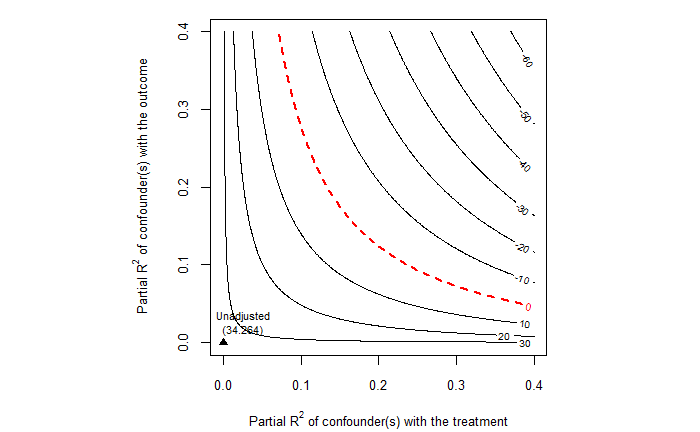

```r
plot(sens)
```

The Unadjusted Estimate of CDL shows that CDL still has a significant positive effect on homicide rates, i.e., an average of about 34 additional murders per state per year after the policy was implemented.

- Partial R² = 0.0301: This means that, assuming the existence of an extreme unobserved confounder that is completely independent of the other control variables, it would need to explain at least 3.01% of the residual variance in order to completely zero out the effect of CDL.
- Robustness Value (q = 1) = 0.1613: If an unobserved confounding variable affects both CDL (policy implementation) and homicide (homicide_c) and explains more than 16.13% of the residual variance, then the estimate of CDL may be biased toward zero.
- Robustness Value (q = 1, α = 0.05) = 0.0824: If an unobserved confounding variable explains more than 8.24% of the variance of the residuals, then the CDL estimate may become less significant (p > 0.05). This means that our results remain robust (i.e., the CDL remains significant) as long as the explanatory power of the unobserved confounders is below 8.24%.

We conclude that the Robustness Value is not high enough and the robustness of the model needs to be improved.

We next compare our sensitivity analysis with that of the model without confounding variables.

```r
DiD.FE.StateYear.lsdv <- lm(homicide_c ~ cdl + factor(state) + factor(year),
               data = merged_data)
sens2 <- sensemakr(model = DiD.FE.StateYear.lsdv, treatment = "cdl")
summary(sens2)
```

```
Sensitivity Analysis to Unobserved Confounding

Model Formula: homicide_c ~ cdl + factor(state) + factor(year)

Null hypothesis: q = 1 and reduce = TRUE
-- This means we are considering biases that reduce the absolute value of the current estimate.
-- The null hypothesis deemed problematic is H0:tau = 0

Unadjusted Estimates of 'cdl':
  Coef. estimate: 33.113
  Standard Error: 8.4754
  t-value (H0:tau = 0): 3.9069

Sensitivity Statistics:
  Partial R2 of treatment with outcome: 0.0303
  Robustness Value, q = 1: 0.1618
  Robustness Value, q = 1, alpha = 0.05: 0.084

Verbal interpretation of sensitivity statistics:

-- Partial R2 of the treatment with the outcome: an extreme confounder (orthogonal to the covariates) that explains 100% of the residual variance of the outcome, would need to explain at least 3.03% of the residual variance of the treatment to fully account for the observed estimated effect.

-- Robustness Value, q = 1: unobserved confounders (orthogonal to the covariates) that explain more than 16.18% of the residual variance of both the treatment and the outcome are strong enough to bring the point estimate to 0 (a bias of 100% of the original estimate). Conversely, unobserved confound…

-- Robustness Value, q = 1, alpha = 0.05: unobserved confounders (orthogonal to the covariates) that explain more than 8.4% of the residual variance of both the treatment and the outcome are strong enough to bring the estimate to a range where it is no longer 'statistically different' from 0 (a bias…
```

We found that when we include all the potential confounders, the robust value decreases, implying that we need to adjust the selection of confounders.

Next, we go on to explore the sensitivity analysis of the models that incorporate them in turn, according to the categories of the different confounding variables.

```r
mod_baseline <- lm(homicide_c ~ cdl + factor(state) + factor(year),
                   data = data)

mod_economic <- lm(homicide_c ~ cdl + unemployrt + income + poverty +
                     factor(state) + factor(year),
                   data = data)

mod_demographics <- lm(homicide_c ~ cdl +
                         blackm_15_24 + whitem_15_24 +
                         blackm_25_44 + whitem_25_44 +
                         factor(state) + factor(year),
                       data = data)

mod_criminal <- lm(homicide_c ~ cdl + prisoner + lagprisoner +
                     factor(state) + factor(year),
                   data = data)

mod_welfare <- lm(homicide_c ~ cdl + exp_subsidy + exp_pubwelfare +
                    factor(state) + factor(year),
                  data = data)

mod_police <- lm(homicide_c ~ cdl + police +
                   factor(state) + factor(year),
                 data = data)

mod_full <- lm(homicide_c ~ cdl +
                 unemployrt + income + poverty +
                 blackm_15_24 + whitem_15_24 +
                 blackm_25_44 + whitem_25_44 +
                 prisoner + lagprisoner +
                 exp_subsidy + exp_pubwelfare +
                 police +
                 factor(state) + factor(year),
               data = data)

coef_table <- tibble(
  Model = c("Baseline", "Economic", "Demographics", "Criminal",
            "Welfare", "Police", "Full"),
  cdl_Coefficient = c(
    coef(mod_baseline)["cdl"],
    coef(mod_economic)["cdl"],
    coef(mod_demographics)["cdl"],
    coef(mod_criminal)["cdl"],
    coef(mod_welfare)["cdl"],
    coef(mod_police)["cdl"],
    coef(mod_full)["cdl"]
  ),
  p_value = c(
    summary(mod_baseline)$coefficients["cdl", "Pr(>|t|)"],
    summary(mod_economic)$coefficients["cdl", "Pr(>|t|)"],
    summary(mod_demographics)$coefficients["cdl", "Pr(>|t|)"],
    summary(mod_criminal)$coefficients["cdl", "Pr(>|t|)"],
    summary(mod_welfare)$coefficients["cdl", "Pr(>|t|)"],
    summary(mod_police)$coefficients["cdl", "Pr(>|t|)"],
    summary(mod_full)$coefficients["cdl", "Pr(>|t|)"]
  )
)
print(coef_table)
```

| Model | cdl_Coefficient | p_value |
| --- | --- | --- |
| Baseline | 33.11300 | 1.066356e-04 |
| Economic | 33.63502 | 7.686324e-05 |
| Demographics | 32.78777 | 1.943924e-04 |
| Criminal | 32.05390 | 2.210152e-04 |
| Welfare | 34.09709 | 7.791680e-05 |
| Police | 34.55231 | 5.722536e-05 |
| Full | 34.26402 | 1.364808e-04 |

```r
NA
```

```r
model_list <- list(
  Baseline = mod_baseline,
  Economic = mod_economic,
  Demographics = mod_demographics,
  Criminal = mod_criminal,
  Welfare = mod_welfare,
  Police = mod_police,
  Full = mod_full
)


get_robust_value <- function(mod) {
  sens_obj <- sensemakr(model = mod, treatment = "cdl")
  rv_q_value <- sens_obj$sensitivity_stats$rv_q

  return(rv_q_value)
}

robust_values <- lapply(model_list, get_robust_value)

print(robust_values)
```

```
$Baseline
[1] 0.162
Parameters: q = 1, alpha = 1, invert = FALSE

$Economic
[1] 0.165
Parameters: q = 1, alpha = 1, invert = FALSE

$Demographics
[1] 0.157
Parameters: q = 1, alpha = 1, invert = FALSE

$Criminal
[1] 0.155
Parameters: q = 1, alpha = 1, invert = FALSE

$Welfare
[1] 0.165
Parameters: q = 1, alpha = 1, invert = FALSE

$Police
[1] 0.168
Parameters: q = 1, alpha = 1, invert = FALSE

$Full
[1] 0.161
Parameters: q = 1, alpha = 1, invert = FALSE
```

We found that our estimates are significant in all cases and that the differences are not significant. However, we found that Demographics and Criminal type potential confounders are making robust value lower than the baseline. Therefore, we believe that these should be removed.

```r
DiD.FE.StateYear.cof.lsdv <- lm(homicide_c ~ cdl + unemployrt + income +
               poverty + exp_subsidy + exp_pubwelfare +
               police + factor(state) + factor(year),
               data = merged_data)
sens <- sensemakr(model = DiD.FE.StateYear.cof.lsdv, treatment = "cdl")
summary(DiD.FE.StateYear.cof.lsdv)
```

```
Call:
lm(formula = homicide_c ~ cdl + unemployrt + income + poverty +
    exp_subsidy + exp_pubwelfare + police + factor(state) + factor(year),
    data = merged_data)

Residuals:
    Min      1Q  Median      3Q     Max
-374.97  -16.93   -2.03   17.27  238.04

Coefficients:
                              Estimate Std. Error t value Pr(>|t|)
(Intercept)                  2.721e+02  9.359e+01   2.907 0.003812 **
cdl                          3.568e+01  8.550e+00   4.174 3.56e-05 ***
unemployrt                  -8.740e+00  2.868e+00  -3.047 0.002437 **
income                       1.353e-04  1.049e-03   0.129 0.897461
poverty                     -5.972e-01  3.907e+00  -0.153 0.878594
exp_subsidy                  2.766e-02  7.264e-02   0.381 0.703493
exp_pubwelfare               1.652e-02  1.860e-02   0.888 0.374910
police                       1.627e-01  1.134e-01   1.434 0.152126
factor(state)Alaska         -3.065e+02  4.179e+01  -7.335 9.41e-13 ***
factor(state)Arizona         9.928e+01  2.133e+01   4.654 4.22e-06 ***
factor(state)Arkansas       -1.382e+02  2.119e+01  -6.520 1.77e-10 ***
factor(state)California      1.931e+03  2.811e+01  68.698  < 2e-16 ***
factor(state)Colorado       -1.564e+02  3.060e+01  -5.111 4.62e-07 ***
factor(state)Connecticut    -2.142e+02  3.667e+01  -5.842 9.51e-09 ***
factor(state)Delaware       -3.050e+02  2.997e+01 -10.177  < 2e-16 ***
factor(state)Florida         6.541e+02  2.459e+01  26.594  < 2e-16 ***
factor(state)Georgia         2.880e+02  2.139e+01  13.466  < 2e-16 ***
factor(state)Hawaii         -3.025e+02  3.137e+01  -9.640  < 2e-16 ***
factor(state)Idaho          -2.794e+02  2.487e+01 -11.233  < 2e-16 ***
factor(state)Illinois        5.024e+02  2.801e+01  17.933  < 2e-16 ***
factor(state)Indiana         2.488e+01  2.710e+01   0.918 0.358980
factor(state)Iowa           -2.734e+02  2.898e+01  -9.435  < 2e-16 ***
factor(state)Kansas         -2.271e+02  2.735e+01  -8.303 1.03e-15 ***
factor(state)Kentucky       -1.190e+02  2.301e+01  -5.174 3.37e-07 ***
factor(state)Louisiana       2.008e+02  2.485e+01   8.083 5.13e-15 ***
factor(state)Maine          -2.981e+02  3.038e+01  -9.812  < 2e-16 ***
factor(state)Maryland        1.576e+02  3.639e+01   4.331 1.81e-05 ***
factor(state)Massachusetts  -1.592e+02  3.299e+01  -4.827 1.87e-06 ***
factor(state)Michigan        3.354e+02  2.685e+01  12.494  < 2e-16 ***
```

[output cut: 29 more lines]

```
factor(year)2002             2.259e+01  1.050e+01   2.152 0.031898 *
factor(year)2003             3.056e+01  1.121e+01   2.725 0.006662 **
factor(year)2004             1.858e+01  1.213e+01   1.532 0.126263
factor(year)2005             2.811e+01  1.322e+01   2.126 0.033974 *
factor(year)2006             3.345e+01  1.224e+01   2.733 0.006509 **
factor(year)2007             2.058e+01  1.247e+01   1.650 0.099569 .
factor(year)2008             1.254e+01  1.288e+01   0.974 0.330641
factor(year)2009             1.681e+01  1.849e+01   0.909 0.363654
factor(year)2010             7.078e+00  1.900e+01   0.373 0.709663
---
Signif. codes:  0 ‘***’ 0.001 ‘**’ 0.01 ‘*’ 0.05 ‘.’ 0.1 ‘ ’ 1

Residual standard error: 45.52 on 483 degrees of freedom
Multiple R-squared:  0.9888,    Adjusted R-squared:  0.9873
F-statistic: 646.8 on 66 and 483 DF,  p-value: < 2.2e-16
```

```r
summary(sens)
```

```
Sensitivity Analysis to Unobserved Confounding

Model Formula: homicide_c ~ cdl + unemployrt + income + poverty + exp_subsidy +
    exp_pubwelfare + police + factor(state) + factor(year)

Null hypothesis: q = 1 and reduce = TRUE
-- This means we are considering biases that reduce the absolute value of the current estimate.
-- The null hypothesis deemed problematic is H0:tau = 0

Unadjusted Estimates of 'cdl':
  Coef. estimate: 35.6848
  Standard Error: 8.5502
  t-value (H0:tau = 0): 4.1735

Sensitivity Statistics:
  Partial R2 of treatment with outcome: 0.0348
  Robustness Value, q = 1: 0.1727
  Robustness Value, q = 1, alpha = 0.05: 0.0955

Verbal interpretation of sensitivity statistics:

-- Partial R2 of the treatment with the outcome: an extreme confounder (orthogonal to the covariates) that explains 100% of the residual variance of the outcome, would need to explain at least 3.48% of the residual variance of the treatment to fully account for the observed estimated effect.

-- Robustness Value, q = 1: unobserved confounders (orthogonal to the covariates) that explain more than 17.27% of the residual variance of both the treatment and the outcome are strong enough to bring the point estimate to 0 (a bias of 100% of the original estimate). Conversely, unobserved confound…

-- Robustness Value, q = 1, alpha = 0.05: unobserved confounders (orthogonal to the covariates) that explain more than 9.55% of the residual variance of both the treatment and the outcome are strong enough to bring the estimate to a range where it is no longer 'statistically different' from 0 (a bia…
```

The result is promising. After removing Demographics and Criminal type potential confounders, the Robustness Value is higher than the previous baseline and full model. This indicates that our OVB problem is solved to more extend with this sensitivity analysis on our dataset. Our model is more robust than before.

# Nationwide DiD/Fixed Effect with IV Exploration

Then, we try IV method combined with DiD/FE.

```r
mod_iv_fe_lsdv <- ivreg(
  homicide_c ~ cdl + unemployrt + income + poverty + exp_subsidy + exp_pubwelfare +
               police + factor(state) + factor(year)
  | unemployrt + income + poverty + exp_subsidy + exp_pubwelfare + police + factor(state) + factor(year) + GunsAmmo + HuntLic ,

  data = merged_data
)

summary(mod_iv_fe_lsdv, diagnostics = TRUE)
```

```
Call:
ivreg(formula = homicide_c ~ cdl + unemployrt + income + poverty +
    exp_subsidy + exp_pubwelfare + police + factor(state) + factor(year) |
    unemployrt + income + poverty + exp_subsidy + exp_pubwelfare +
        police + factor(state) + factor(year) + GunsAmmo + HuntLic,
    data = merged_data)

Residuals:
     Min       1Q   Median       3Q      Max
-341.517  -32.841   -1.921   33.626  221.899

Coefficients:
                              Estimate Std. Error t value Pr(>|t|)
(Intercept)                  1.583e+02  1.264e+02   1.252 0.211138
cdl                          1.660e+02  6.360e+01   2.610 0.009331 **
unemployrt                  -6.668e+00  3.630e+00  -1.837 0.066856 .
income                       9.183e-04  1.332e-03   0.690 0.490730
poverty                     -4.078e+00  5.042e+00  -0.809 0.419006
exp_subsidy                 -1.746e-02  9.103e-02  -0.192 0.847964
exp_pubwelfare               5.004e-02  2.780e-02   1.800 0.072491 .
police                       3.592e-01  1.674e-01   2.146 0.032338 *
factor(state)Alaska         -3.695e+02  5.921e+01  -6.241 9.53e-10 ***
factor(state)Arizona         8.215e+01  2.724e+01   3.016 0.002699 **
factor(state)Arkansas       -8.034e+01  3.796e+01  -2.116 0.034821 *
factor(state)California      1.944e+03  3.474e+01  55.946  < 2e-16 ***
factor(state)Colorado       -1.336e+02  3.883e+01  -3.442 0.000628 ***
factor(state)Connecticut    -2.073e+02  4.476e+01  -4.631 4.68e-06 ***
factor(state)Delaware       -3.007e+02  3.654e+01  -8.231 1.75e-15 ***
factor(state)Florida         6.205e+02  3.401e+01  18.247  < 2e-16 ***
factor(state)Georgia         2.758e+02  2.668e+01  10.336  < 2e-16 ***
factor(state)Hawaii         -2.780e+02  3.996e+01  -6.955 1.15e-11 ***
factor(state)Idaho          -2.276e+02  3.920e+01  -5.807 1.15e-08 ***
factor(state)Illinois        5.110e+02  3.434e+01  14.878  < 2e-16 ***
factor(state)Indiana         1.708e+01  3.319e+01   0.515 0.607004
factor(state)Iowa           -2.346e+02  3.993e+01  -5.875 7.87e-09 ***
factor(state)Kansas         -2.564e+02  3.616e+01  -7.092 4.72e-12 ***
factor(state)Kentucky       -1.140e+02  2.810e+01  -4.055 5.85e-05 ***
factor(state)Louisiana       1.884e+02  3.083e+01   6.109 2.07e-09 ***
factor(state)Maine          -2.661e+02  4.006e+01  -6.642 8.36e-11 ***
factor(state)Maryland        1.621e+02  4.435e+01   3.656 0.000284 ***
```

[output cut: 37 more lines]

```
factor(year)2008            -4.479e+01  3.174e+01  -1.411 0.158827
factor(year)2009            -5.001e+01  3.926e+01  -1.274 0.203362
factor(year)2010            -6.146e+01  4.029e+01  -1.525 0.127827

Diagnostic tests:
                 df1 df2 statistic p-value
Weak instruments   2 482     6.628 0.00145 **
Wu-Hausman         1 482     6.462 0.01133 *
Sargan             1  NA     0.615 0.43299
---
Signif. codes:  0 ‘***’ 0.001 ‘**’ 0.01 ‘*’ 0.05 ‘.’ 0.1 ‘ ’ 1

Residual standard error: 55.39 on 483 degrees of freedom
Multiple R-Squared: 0.9834, Adjusted R-squared: 0.9812
Wald test: 436.7 on 66 and 483 DF,  p-value: < 2.2e-16
```

To evaluate the validity of IV:

Relevance Restriction: Common sense suggests that the proportion of hunting licenses and the amount of ammunition in the home are highly correlated with gun availability. Gun availability, in turn, is in turn related to attitudes toward firearms-related bills, i.e., a state with more guns is more likely to favor laws that support their gun-related activities. The Weak instruments suggests that this is satisfied.

Exclusion Restriction: According to [Frederic Lemieux (2014)](https://ijcjs.com/menu-script/index.php/ijcjs/article/view/149), gun culture (e.g., legal hunting, shooting activities) does not directly lead to an increase in homicides among cities or residents. The study suggests that the key determinant of gun violence is the gun law environment, not the gun culture itself. Strict gun control regulations significantly reduce gun violence and mortality rates, while the effects of gun culture are primarily transmitted indirectly through the legislative environment. Therefore, it is reasonable to assume that, i.e., legal hunting and magazine subscription are not directly and significantly causally related to homicides, and that the main avenue of influence is legislative regulation of gun availability. This proves that the Exclusion Restriction of our instrumental variable is satisfied.

Independence Restriction: Our Sargan test demonstrates that our two instrumental variables are not related to potential OVB.

We therefore conclude that based on the DiD and FE methods that incorporate IV our model estimates our ATE to be approximately 36 (without IV) and 166 (with IV). This suggests that passing a castle law would boost the number of homicides in the state by 36/166 on average. Suggesting that our laws do not have a good effect.

# Synthetic DiD

Above analysis highlighted the importance of controlling for heterogeneity in covariates to ensure robust causal inference. To further enhance our estimation strategy, we now explore methods that address potential biases and improve treatment effect estimation. We first implement Synthetic Difference-in-Differences (DiD) to construct a more credible counterfactual for the treated group.

Install synthdid from github

```r
#Run below code if devtools is not installed

#install.packages("devtools")  #Install devtools
#library(devtools)
#devtools::install_github("synth-inference/synthdid")  #Install synthdid from github
```

```r
library(synthdid) #Load synthdid
```

Check number of states passed CDL in different years

```r
law_adoption_summary <- data %>%
  filter(effyear > 0) %>%  # Filter out states that never pass CDL（effyear = 0）
  distinct(state, effyear) %>%
  group_by(effyear) %>%
  summarise(
    num_states = n(),
    states = paste(state, collapse = ", ")
  ) %>%
  arrange(effyear)

print(law_adoption_summary)
```

| effyear | num_states | states |
| --- | --- | --- |
| 2005 | 1 | Florida |
| 2006 | 13 | Alabama, Alaska, Arizona, Georgia, Indiana, Kansas, Kentucky, Louisiana, Michigan, Mississippi, Oklahoma, South Carolina, South Dakota |
| 2007 | 4 | Missouri, North Dakota, Tennessee, Texas |
| 2008 | 2 | Ohio, West Virginia |
| 2009 | 1 | Montana |

We see that 2006 has the highest number of states passed CDL (13). Since synthdid and panel.matrices cannot use data where treatment is not simultaneous, we will keep only the states that passed CDL in 2006 for simplicity.

Data processing

```r
sdid_data <- data %>%
  filter(effyear == 2006 | effyear == 0) %>%
  mutate(
    year = as.integer(as.character(year)),
  )
```

```r
# synthetic DiD for log_homicide
sdid_mats <- panel.matrices(as.data.frame(
  sdid_data),
  unit      = "state",
  time      = "year",
  outcome   = "log_homicide",
  treatment = "post"
)
```

```r
# Check dimensions
dim(sdid_mats$Y)    # (num_units x num_time_periods)
```

```
[1] 42 11
```

```r
sdid_mats$N0 # number of states
```

```
[1] 29
```

```r
sdid_mats$T0 # number of years before CDL passed
```

```
[1] 6
```

Run the Synthetic DiD estimator

```r
# ATT
tau.hat <- synthdid_estimate(
  Y  = sdid_mats$Y,
  N0 = sdid_mats$N0,
  T0 = sdid_mats$T0
)

summary(tau.hat)
```

```
$estimate
[1] 0.06130664

$se
           [,1]
[1,] 0.04058065

$controls
               estimate 1
Hawaii              0.044
Iowa                0.041
Illinois            0.040
Minnesota           0.040
Nebraska            0.040
Utah                0.040
New Hampshire       0.039
Vermont             0.039
Connecticut         0.038
New York            0.038
Oregon              0.036
Maine               0.036
Colorado            0.035
Wisconsin           0.034
Arkansas            0.034
Washington          0.034
Rhode Island        0.034
North Carolina      0.033
California          0.033
Nevada              0.033
Virginia            0.032
New Jersey          0.032
Pennsylvania        0.031
Maryland            0.031
Massachusetts       0.028
New Mexico          0.028

$periods
     estimate 1
2005      0.539
2004      0.415

$dimensions
          N1           N0 N0.effective           T1           T0 T0.effective
      13.000       29.000       28.446        5.000        6.000        2.152
```

Here we are using log_homicide as the outcome variable. The estimated Average Treatment Effect on the Treated (ATT) is 0.0613, suggesting that the adoption of CDL is associated with a 6.1% increase in homicide rates on a log scale.

```r
se = sqrt(vcov(tau.hat, method='placebo'))

sprintf('point estimate: %1.2f', tau.hat) #ATT
```

```
[1] "point estimate: 0.06"
```

```r
sprintf('95%% CI (%1.2f, %1.2f)', tau.hat - 1.96 * se, tau.hat + 1.96 * se) #95% CI
```

```
[1] "95% CI (-0.02, 0.15)"
```

The 95% CI includes 0, we cannot reject the null hypothesis that ATT = 0 and the ATT is not statistically significant.

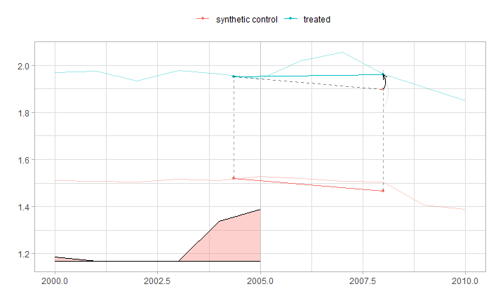

```r
synthdid_plot(tau.hat)
```

Before 2006, the trends between treated and synthetic control states are relatively parallel, supporting the parallel trends assumption. After CDL implementation in 2006, the treated group diverges upward while the synthetic control remains stable, suggesting a potential increase in log homicide rates due to CDL.

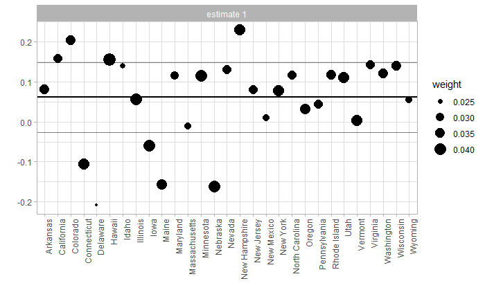

```r
synthdid_units_plot(tau.hat, se.method='placebo')
```

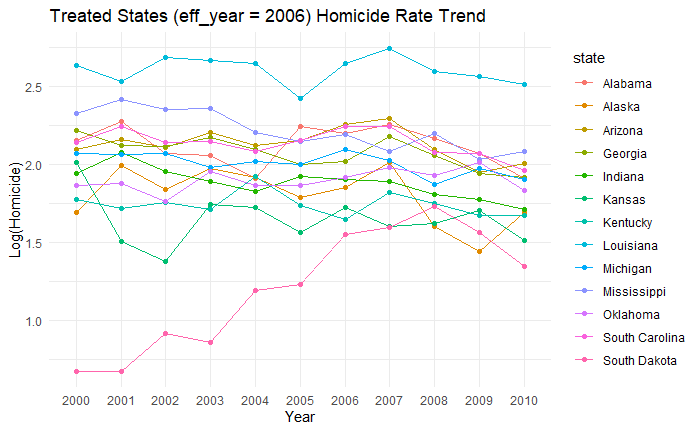

```r
state2006 <- data %>%
  filter(effyear == 2006)

ggplot(state2006, aes(x = year, y = log_homicide, group = state, color = state)) +
  geom_line() +
  geom_point() +
  labs(title = "Treated States (eff_year = 2006) Homicide Rate Trend",
       x = "Year",
       y = "Log(Homicide)") +
  theme_minimal()
```

We see that among states passed CDL in 2006, they have quite different trend of log_homicide throughout time. This heterogeneity suggests that a single Synthetic DiD estimation may not capture the full effect, motivating further analysis on individual states. As a next step, we will apply Synthetic DiD to selected states individually to better isolate treatment effects.

Alabama

```r
sdid_data_AL <- sdid_data %>%
  filter(state == 'Alabama' | effyear == 0) %>%
  mutate(
    year = as.integer(as.character(year)),
  )
```

```r
sdid_mats_AL <- panel.matrices(
  as.data.frame(sdid_data_AL),
  unit      = "state",
  time      = "year",
  outcome   = "log_homicide",
  treatment = "post"
)

dim(sdid_mats_AL$Y)    # (num_units x num_time_periods)
```

```
[1] 30 11
```

```r
sdid_mats_AL$N0 # number of states
```

```
[1] 29
```

```r
sdid_mats_AL$T0 # number of years before CDL passed
```

```
[1] 6
```

```r
tau.hat_AL <- synthdid_estimate(
  Y  = sdid_mats_AL$Y,
  N0 = sdid_mats_AL$N0,
  T0 = sdid_mats_AL$T0
)

summary(tau.hat_AL)
```

```
$estimate
[1] 0.08063975

$se
     [,1]
[1,]   NA

$controls
               estimate 1
Rhode Island        0.161
Wisconsin           0.125
Utah                0.121
Nevada              0.062
New Hampshire       0.060
Delaware            0.059
Pennsylvania        0.053
Maine               0.053
Illinois            0.052
Connecticut         0.042
Virginia            0.033
North Carolina      0.030
Minnesota           0.030
New York            0.027

$periods
     estimate 1
2005      0.539
2004      0.415

$dimensions
          N1           N0 N0.effective           T1           T0 T0.effective
       1.000       29.000       12.108        5.000        6.000        2.152
```

```r
se = sqrt(vcov(tau.hat_AL, method='placebo'))

sprintf('point estimate AL: %1.2f', tau.hat_AL) #ATT
```

```
[1] "point estimate AL: 0.08"
```

```r
sprintf('95%% CI AL(%1.2f, %1.2f)', tau.hat_AL - 1.96 * se, tau.hat_AL + 1.96 * se) #95% CI
```

```
[1] "95% CI AL(-0.15, 0.31)"
```

The point estimate for Alabama is 0.08, suggesting a 8.4% increase in homicide rates following CDL adoption. However, the 95% confidence interval (-0.15, 0.31) includes zero, indicating that this estimate is not statistically significant.

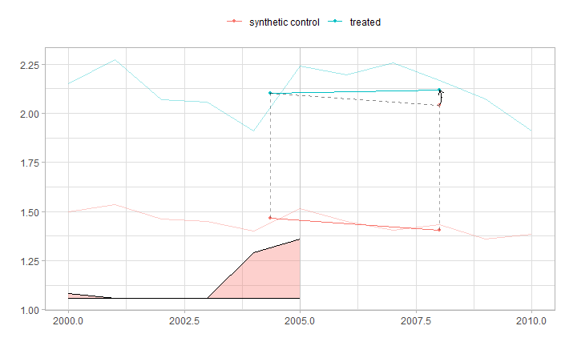

```r
synthdid_plot(tau.hat_AL)
```

Louisiana

```r
sdid_data_LA <- sdid_data %>%
  filter(state == 'Louisiana' | effyear == 0) %>%
  mutate(
    year = as.integer(as.character(year)),
  )
```

```r
sdid_mats_LA <- panel.matrices(
  as.data.frame(sdid_data_LA),
  unit      = "state",
  time      = "year",
  outcome   = "log_homicide",
  treatment = "post"
)
```

```r
tau.hat_LA <- synthdid_estimate(
  Y  = sdid_mats_LA$Y,
  N0 = sdid_mats_LA$N0,
  T0 = sdid_mats_LA$T0
)

summary(tau.hat_LA)
```

```
$estimate
[1] 0.1278997

$se
     [,1]
[1,]   NA

$controls
               estimate 1
Vermont             0.183
Illinois            0.094
Nebraska            0.089
Iowa                0.072
Hawaii              0.064
Minnesota           0.061
Colorado            0.061
New Mexico          0.058
New York            0.056
Wyoming             0.047
Rhode Island        0.036
California          0.029
North Carolina      0.026
Washington          0.023

$periods
     estimate 1
2005      0.539
2004      0.415

$dimensions
          N1           N0 N0.effective           T1           T0 T0.effective
       1.000       29.000       12.364        5.000        6.000        2.152
```

```r
se = sqrt(vcov(tau.hat_LA, method='placebo'))

sprintf('point estimate LA: %1.2f', tau.hat_LA) #ATT
```

```
[1] "point estimate LA: 0.13"
```

```r
sprintf('95%% CI LA(%1.2f, %1.2f)', tau.hat_LA - 1.96 * se, tau.hat_LA + 1.96 * se) #95% CI
```

```
[1] "95% CI LA(-0.15, 0.40)"
```

The point estimate for Louisana is 0.13, suggesting a 13% increase in homicide rates following CDL adoption. However, the 95% confidence interval (-0.15, 0.40) includes zero, indicating that this estimate is not statistically significant.

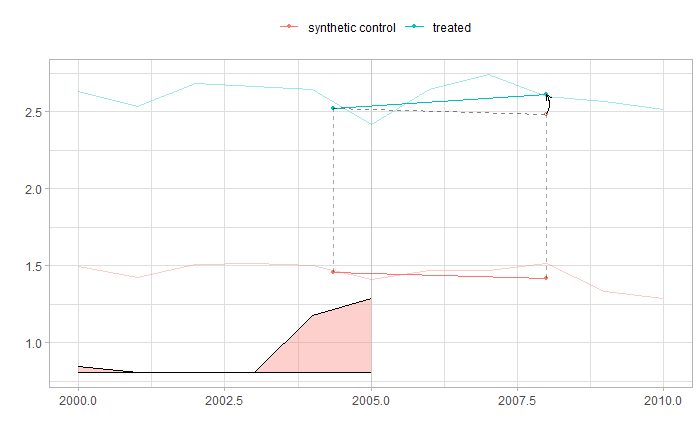

```r
synthdid_plot(tau.hat_LA)
```

South Dakota

```r
sdid_data_SD <- sdid_data %>%
  filter(state == 'South Dakota' | effyear == 0) %>%
  mutate(
    year = as.integer(as.character(year)),
  )
```

```r
sdid_mats_SD <- panel.matrices(
  as.data.frame(sdid_data_SD),
  unit      = "state",
  time      = "year",
  outcome   = "log_homicide",
  treatment = "post"
)
```

```r
tau.hat_SD <- synthdid_estimate(
  Y  = sdid_mats_SD$Y,
  N0 = sdid_mats_SD$N0,
  T0 = sdid_mats_SD$T0
)

summary(tau.hat_SD)
```

```
$estimate
[1] 0.378695

$se
     [,1]
[1,]   NA

$controls
              estimate 1
Delaware           0.179
New Mexico         0.163
New Jersey         0.129
Idaho              0.126
Massachusetts      0.122
Vermont            0.075
Maryland           0.065
Arkansas           0.055

$periods
     estimate 1
2005      0.539
2004      0.415

$dimensions
          N1           N0 N0.effective           T1           T0 T0.effective
       1.000       29.000        8.148        5.000        6.000        2.152
```

```r
se = sqrt(vcov(tau.hat_SD, method='placebo'))

sprintf('point estimate SD: %1.2f', tau.hat_SD) #ATT
```

```
[1] "point estimate SD: 0.38"
```

```r
sprintf('95%% CI SD(%1.2f, %1.2f)', tau.hat_SD - 1.96 * se, tau.hat_SD + 1.96 * se) #95% CI
```

```
[1] "95% CI SD(0.14, 0.62)"
```

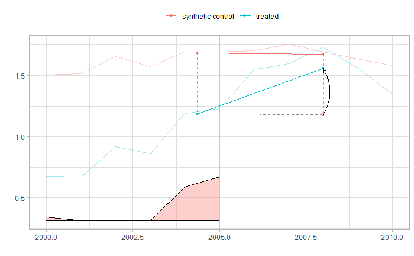

```r
synthdid_plot(tau.hat_SD)
```

# Meta Learners

Data Preparation

```r
df <- data %>%
  select(
    Y = log_homicide,
    W = post,
    #X
    population,
    police,
    unemployrt,
    income,
    blackm_15_24,
    whitem_15_24,
    blackm_25_44,
    whitem_25_44,
    prisoner,
    poverty,
    exp_subsidy,
    exp_pubwelfare
  ) %>%
  drop_na()

Y <- df$Y
W <- df$W

X <- df %>%
  select(
    population,
    police,
    unemployrt,
    income,
    blackm_15_24,
    whitem_15_24,
    blackm_25_44,
    whitem_25_44,
    prisoner,
    poverty,
    exp_subsidy,
    exp_pubwelfare
  ) %>%
  as.matrix()
```

T-Learner

```r
df_treated <- df %>% filter(W == 1)
df_control <- df %>% filter(W == 0)
```

```r
model_treated <- randomForest(
  Y ~ population + police + unemployrt + income +
    blackm_15_24 + whitem_15_24 + blackm_25_44 + whitem_25_44 +
    prisoner + poverty + exp_subsidy + exp_pubwelfare,
  data = df_treated
)
model_control <- randomForest(
  Y ~ population + police + unemployrt + income +
    blackm_15_24 + whitem_15_24 + blackm_25_44 + whitem_25_44 +
    prisoner + poverty + exp_subsidy + exp_pubwelfare,
  data = df_control
)
```

```r
Yhat_treated  <- predict(model_treated, newdata = df)
Yhat_control  <- predict(model_control, newdata = df)
```

```r
tau_hat_T     <- Yhat_treated - Yhat_control
ATE_t_learner <- mean(tau_hat_T)

cat("T-Learner ATE:", ATE_t_learner, "\n")
```

```
T-Learner ATE: 0.142489
```

The T-Learner trains two separate Random Forest regression models. One model (treated group) is trained using data where W=1. Another model (control group) is trained using data where W=0. Predictions for both models are generated for all observations, and the treatment effect is estimated as the difference between predicted values. The Average Treatment Effect (ATE) for the T-Learner is 0.1425, suggesting a 15.3% increase in homicide rates due to CDL implementation.

S-Learner

```r
model_s <- randomForest(
  Y ~ W + population + police + unemployrt + income +
    blackm_15_24 + whitem_15_24 + blackm_25_44 + whitem_25_44 +
    prisoner + poverty + exp_subsidy + exp_pubwelfare,
  data = df
)
```

```r
df_w1 <- df %>% mutate(W = 1)
df_w0 <- df %>% mutate(W = 0)

Yhat_w1 <- predict(model_s, newdata = df_w1)
Yhat_w0 <- predict(model_s, newdata = df_w0)
```

```r
tau_hat_S <- Yhat_w1 - Yhat_w0
ATE_s_learner <- mean(tau_hat_S)

cat("S-Learner ATE:", ATE_s_learner, "\n")
```

```
S-Learner ATE: 0.007434145
```

The S-Learner uses a single Random Forest model, where treatment status (W) is included as a predictor along with all covariates. The model predicts homicide rates under two counterfactual scenarios. For all observations if they were treated and for all observations if they were not treated. The Average Treatment Effect (ATE) for the S-Learner is 0.0074, translating to a 0.74% increase in homicide rates, which is substantially lower than the T-Learner estimate.

Significance test: confidence intervals for T-Learner ATE estimated using Bootstrap

```r
set.seed(123)  # Set Seed
B <- 200       # Bootstrap repetition
n <- nrow(df)

ATE_bootstrap_T <- numeric(B)

for (b in 1:B) {
  # 1. bootstrap sampling
  idx <- sample(seq_len(n), size = n, replace = TRUE)
  df_boot <- df[idx, ]

  # 2. Split data
  df_treated_boot <- df_boot %>% filter(W == 1)
  df_control_boot <- df_boot %>% filter(W == 0)

  # 3. Train
  model_treated_boot <- randomForest(
    Y ~ population + police + unemployrt + income +
      blackm_15_24 + whitem_15_24 + blackm_25_44 + whitem_25_44 +
      prisoner + poverty + exp_subsidy + exp_pubwelfare,
    data = df_treated_boot
  )

  model_control_boot <- randomForest(
    Y ~ population + police + unemployrt + income +
      blackm_15_24 + whitem_15_24 + blackm_25_44 + whitem_25_44 +
      prisoner + poverty + exp_subsidy + exp_pubwelfare,
    data = df_control_boot
  )

  # 4. ITE and ATE
  Yhat_treated_boot  <- predict(model_treated_boot, newdata = df_boot)
  Yhat_control_boot  <- predict(model_control_boot, newdata = df_boot)

  tau_hat_boot <- Yhat_treated_boot - Yhat_control_boot
  ATE_bootstrap_T[b] <- mean(tau_hat_boot)
}

# mean of Bootstrap distribution and 95% CI
ATE_mean_T <- mean(ATE_bootstrap_T)
CI_lower_T <- quantile(ATE_bootstrap_T, probs = 0.025)
CI_upper_T <- quantile(ATE_bootstrap_T, probs = 0.975)

cat("T-Learner Bootstrap ATE:", ATE_mean_T, "\n")
```

```
T-Learner Bootstrap ATE: 0.1443648
```

```r
cat("95% CI:", CI_lower_T, "~", CI_upper_T, "\n")
```

```
95% CI: 0.0998704 ~ 0.1911359
```

T-Learner Result is statistically significant.

Significance test: confidence intervals for S-Learner ATE estimated using Bootstrap

```r
ATE_bootstrap_S <- numeric(B)

for (b in 1:B) {
  # 1) Bootstrap sampling index
  idx <- sample(seq_len(n), size = n, replace = TRUE)
  df_boot <- df[idx, ]

  # 2) Fit the S-Learner on bootstrap sample
  model_s_boot <- randomForest(
    Y ~ W + population + police + unemployrt + income +
      blackm_15_24 + whitem_15_24 + blackm_25_44 + whitem_25_44 +
      prisoner + poverty + exp_subsidy + exp_pubwelfare,
    data = df_boot
  )

  # 3) W=1 and W=0
  df_boot_w1 <- df_boot %>% mutate(W = 1)
  df_boot_w0 <- df_boot %>% mutate(W = 0)

  # 4) Predict Y(W=1) and Y(W=0)
  Yhat_w1_S_boot <- predict(model_s_boot, newdata = df_boot_w1)
  Yhat_w0_S_boot <- predict(model_s_boot, newdata = df_boot_w0)

  # 5) ITE
  tau_hat_S_boot <- Yhat_w1_S_boot - Yhat_w0_S_boot

  # 6) ATE
  ATE_bootstrap_S[b] <- mean(tau_hat_S_boot)
}

# mean of Bootstrap distribution and 95% CI
ATE_mean_S <- mean(ATE_bootstrap_S)
CI_lower_S <- quantile(ATE_bootstrap_S, probs = 0.025)
CI_upper_S <- quantile(ATE_bootstrap_S, probs = 0.975)

cat("S-Learner Bootstrap ATE:", ATE_mean_S, "\n")
```

```
S-Learner Bootstrap ATE: 0.007427788
```

```r
cat("95% CI:", CI_lower_S, "~", CI_upper_S, "\n")
```

```
95% CI: 0.001986627 ~ 0.01567021
```

S-Learner Result is statistically significant.

HTE

```r
df_subgroup <- df %>%
  mutate(
    tau_T = tau_hat_T,  # T-Learner ITE
    tau_S = tau_hat_S,  # S-Learner ITE
    group_income = ifelse(income < median(income), "Low Income", "High Income")
  )

df_subgroup %>%
  group_by(group_income) %>%
  summarise(
    mean_tau_T = mean(tau_T),
    mean_tau_S = mean(tau_S),
    n = n()
  )
```

| group_income | mean_tau_T | mean_tau_S | n |
| --- | --- | --- | --- |
| High Income | 0.22158140 | 0.006585178 | 275 |
| Low Income | 0.06339657 | 0.008283112 | 275 |

We divide the data into high-income and low-income groups based on the median income and estimates the average treatment effect (ATE) within each subgroup using both meta-learning approaches.

```r
t_test_result <- t.test(
  df_subgroup$tau_T[df_subgroup$group_income == "Low Income"],
  df_subgroup$tau_T[df_subgroup$group_income == "High Income"]
)

t_test_result
```

```
    Welch Two Sample t-test

data:  df_subgroup$tau_T[df_subgroup$group_income == "Low Income"] and df_subgroup$tau_T[df_subgroup$group_income == "High Income"]
t = -6.4101, df = 545.62, p-value = 3.149e-10
alternative hypothesis: true difference in means is not equal to 0
95 percent confidence interval:
 -0.2066589 -0.1097107
sample estimates:
 mean of x  mean of y
0.06339657 0.22158140
```

There is a significant difference between the high-income and low-income groups in the T-Learner estimated ITE

```r
t_test_result_S <- t.test(
  df_subgroup$tau_S[df_subgroup$group_income == "Low Income"],
  df_subgroup$tau_S[df_subgroup$group_income == "High Income"]
)

t_test_result_S
```

```
    Welch Two Sample t-test

data:  df_subgroup$tau_S[df_subgroup$group_income == "Low Income"] and df_subgroup$tau_S[df_subgroup$group_income == "High Income"]
t = 1.3106, df = 436.11, p-value = 0.1907
alternative hypothesis: true difference in means is not equal to 0
95 percent confidence interval:
 -0.0008483725  0.0042442412
sample estimates:
  mean of x   mean of y
0.008283112 0.006585178
```

No significant difference between the high-income and low-income groups in the S-Learner estimated ITE

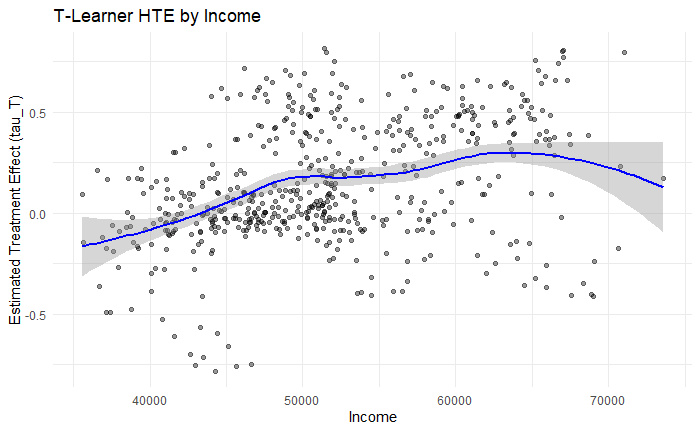

```r
ggplot(df_subgroup, aes(x = income, y = tau_T)) +
  geom_point(alpha = 0.4) +
  geom_smooth(method = "loess", se = TRUE, color = "blue") +
  labs(title = "T-Learner HTE by Income",
       x = "Income",
       y = "Estimated Treatment Effect (tau_T)") +
  theme_minimal()
```

The scatter plot shows a positive relationship between income and estimated treatment effects.

```r
df_subgroup <- df %>%
  mutate(
    tau_T = tau_hat_T,  # T-Learner ITE
    tau_S = tau_hat_S,  # S-Learner ITE

    # Categorize by median black male age 15-24
    group_black_15_24 = ifelse(blackm_15_24 < median(blackm_15_24, na.rm = TRUE), "Low BlackM 15-24", "High BlackM 15-24"),

    # Categorize by median black male age 25-44
    group_black_25_44 = ifelse(blackm_25_44 < median(blackm_25_44, na.rm = TRUE), "Low BlackM 25-44", "High BlackM 25-44")
  )

# Group by Black Male 15-24 percentage and compute mean tau
df_subgroup %>%
  group_by(group_black_15_24) %>%
  summarise(
    mean_tau_T = mean(tau_T),
    mean_tau_S = mean(tau_S),
    n = n()
  )
```

| group_black_15_24 | mean_tau_T | mean_tau_S | n |
| --- | --- | --- | --- |
| High BlackM 15-24 | 0.1723487 | 0.011115739 | 275 |
| Low BlackM 15-24 | 0.1126293 | 0.003752551 | 275 |

```r
# Group by Black Male 25-44 percentage and compute mean tau
df_subgroup %>%
  group_by(group_black_25_44) %>%
  summarise(
    mean_tau_T = mean(tau_T),
    mean_tau_S = mean(tau_S),
    n = n()
  )
```

| group_black_25_44 | mean_tau_T | mean_tau_S | n |
| --- | --- | --- | --- |
| High BlackM 25-44 | 0.1531766 | 0.010769008 | 275 |
| Low BlackM 25-44 | 0.1318014 | 0.004099282 | 275 |

```r
# T-test for Black Male 15-24 using T-Learner estimates
t_test_result_15_24_T <- t.test(
  df_subgroup$tau_T[df_subgroup$group_black_15_24 == "Low BlackM 15-24"],
  df_subgroup$tau_T[df_subgroup$group_black_15_24 == "High BlackM 15-24"]
)

# T-test for Black Male 15-24 using S-Learner estimates
t_test_result_15_24_S <- t.test(
  df_subgroup$tau_S[df_subgroup$group_black_15_24 == "Low BlackM 15-24"],
  df_subgroup$tau_S[df_subgroup$group_black_15_24 == "High BlackM 15-24"]
)

# T-test for Black Male 25-44 using T-Learner estimates
t_test_result_25_44_T <- t.test(
  df_subgroup$tau_T[df_subgroup$group_black_25_44 == "Low BlackM 25-44"],
  df_subgroup$tau_T[df_subgroup$group_black_25_44 == "High BlackM 25-44"]
)

# T-test for Black Male 25-44 using S-Learner estimates
t_test_result_25_44_S <- t.test(
  df_subgroup$tau_S[df_subgroup$group_black_25_44 == "Low BlackM 25-44"],
  df_subgroup$tau_S[df_subgroup$group_black_25_44 == "High BlackM 25-44"]
)

# Print the results
t_test_result_15_24_T
```

```
    Welch Two Sample t-test

data:  df_subgroup$tau_T[df_subgroup$group_black_15_24 == "Low BlackM 15-24"] and df_subgroup$tau_T[df_subgroup$group_black_15_24 == "High BlackM 15-24"]
t = -2.3458, df = 500.5, p-value = 0.01938
alternative hypothesis: true difference in means is not equal to 0
95 percent confidence interval:
 -0.109737527 -0.009701167
sample estimates:
mean of x mean of y
0.1126293 0.1723487
```

```r
t_test_result_15_24_S
```

```
    Welch Two Sample t-test

data:  df_subgroup$tau_S[df_subgroup$group_black_15_24 == "Low BlackM 15-24"] and df_subgroup$tau_S[df_subgroup$group_black_15_24 == "High BlackM 15-24"]
t = -5.849, df = 346.27, p-value = 1.145e-08
alternative hypothesis: true difference in means is not equal to 0
95 percent confidence interval:
 -0.009839208 -0.004887167
sample estimates:
  mean of x   mean of y
0.003752551 0.011115739
```

```r
t_test_result_25_44_T
```

```
    Welch Two Sample t-test

data:  df_subgroup$tau_T[df_subgroup$group_black_25_44 == "Low BlackM 25-44"] and df_subgroup$tau_T[df_subgroup$group_black_25_44 == "High BlackM 25-44"]
t = -0.83597, df = 512.11, p-value = 0.4036
alternative hypothesis: true difference in means is not equal to 0
95 percent confidence interval:
 -0.07160915  0.02885863
sample estimates:
mean of x mean of y
0.1318014 0.1531766
```

```r
t_test_result_25_44_S
```

```
    Welch Two Sample t-test

data:  df_subgroup$tau_S[df_subgroup$group_black_25_44 == "Low BlackM 25-44"] and df_subgroup$tau_S[df_subgroup$group_black_25_44 == "High BlackM 25-44"]
t = -5.2687, df = 344.96, p-value = 2.426e-07
alternative hypothesis: true difference in means is not equal to 0
95 percent confidence interval:
 -0.009159613 -0.004179839
sample estimates:
  mean of x   mean of y
0.004099282 0.010769008
```

For Black males aged 15-24, both T-Learner and S-Learner show statistically significant higher mean treatment effect for areas with a high percentage of Black males aged 15-24 compared to areas with a low percentage. This suggests that Castle Doctrine laws have a significantly stronger impact on homicides in areas with a higher proportion of Black males aged 15-24.

For Black males aged 25-44, T-Learner shows no statistical significance. But S-Learner’s estimate is still statistically significant. S-Learner suggests that Castle Doctrine laws have a slightly stronger impact in areas with more Black males aged 25-44.

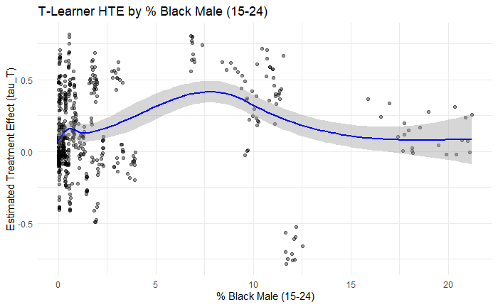

```r
ggplot(df_subgroup, aes(x = blackm_15_24, y = tau_T)) +
  geom_point(alpha = 0.4) +
  geom_smooth(method = "loess", se = TRUE, color = "blue") +
  labs(title = "T-Learner HTE by % Black Male (15-24)",
       x = "% Black Male (15-24)",
       y = "Estimated Treatment Effect (tau_T)") +
  theme_minimal()
```

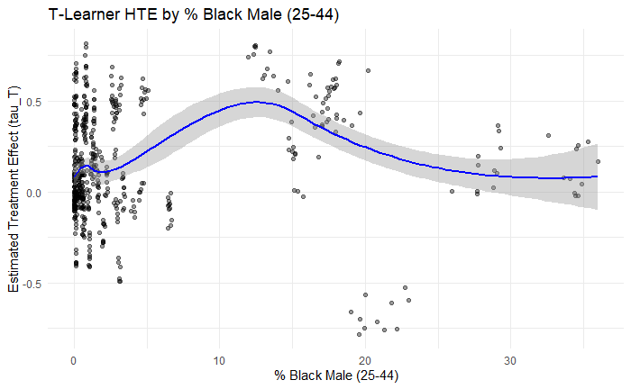

```r
ggplot(df_subgroup, aes(x = blackm_25_44, y = tau_T)) +
  geom_point(alpha = 0.4) +
  geom_smooth(method = "loess", se = TRUE, color = "blue") +
  labs(title = "T-Learner HTE by % Black Male (25-44)",
       x = "% Black Male (25-44)",
       y = "Estimated Treatment Effect (tau_T)") +
  theme_minimal()
```

The plots suggest that Castle Doctrine laws have the strongest effects at moderate levels of Black male population share, rather than in areas with extremely high or low proportions.

# Causal Random Forest

```r
cf_fit <- causal_forest(
  X,
  Y,
  W,
  tune.parameters = "all"
)

cat("\n")
```

```r
summary(cf_fit)
```

```
                         Length Class         Mode
_ci_group_size              1   -none-        numeric
_num_variables              1   -none-        numeric
_num_trees                  1   -none-        numeric
_root_nodes              2000   -none-        list
_child_nodes             2000   -none-        list
_leaf_samples            2000   -none-        list
_split_vars              2000   -none-        list
_split_values            2000   -none-        list
_drawn_samples           2000   -none-        list
_send_missing_left       2000   -none-        list
_pv_values               2000   -none-        list
_pv_num_types               1   -none-        numeric
predictions               550   -none-        numeric
variance.estimates          0   -none-        numeric
debiased.error            550   -none-        numeric
excess.error              550   -none-        numeric
seed                        1   -none-        numeric
num.threads                 1   -none-        numeric
ci.group.size               1   -none-        numeric
X.orig                   6600   -none-        numeric
Y.orig                    550   -none-        numeric
W.orig                    550   -none-        numeric
Y.hat                     550   -none-        numeric
W.hat                     550   -none-        numeric
clusters                    0   -none-        numeric
equalize.cluster.weights    1   -none-        logical
tunable.params              7   -none-        list
tuning.output               4   tuning_output list
has.missing.values          1   -none-        logical
```

```r
ate_cf  <- average_treatment_effect(cf_fit)
cat("\n")
```

```r
ate_cf
```

```
  estimate    std.err
0.04512054 0.01652548
```

```r
sprintf('95%% CI CRF ATE(%1.3f, %1.3f)', ate_cf[1] - 1.96 * ate_cf[2], ate_cf[1] + 1.96 * ate_cf[2]) #95% CI
```

```
[1] "95% CI CRF ATE(0.013, 0.078)"
```

The ATE is statistically significant. When transformed back to percentage terms, this implies a 4.61% increase in homicide rates.

```r
varimp <- variable_importance(cf_fit)
ranked.vars <- order(varimp, decreasing = TRUE)
cat("Feature importance (descending):\n")
```

```
Feature importance (descending):
```

```r
colnames(X)[ranked.vars]
```

```
 [1] "poverty"        "income"         "exp_subsidy"    "exp_pubwelfare" "unemployrt"     "population"     "prisoner"
 [8] "police"         "blackm_15_24"   "whitem_15_24"   "blackm_25_44"   "whitem_25_44"
```

```r
blp_result <- best_linear_projection(cf_fit, X[, ranked.vars])
blp_result
```

```
Best linear projection of the conditional average treatment effect.
Confidence intervals are cluster- and heteroskedasticity-robust (HC3):

                  Estimate  Std. Error t value Pr(>|t|)
(Intercept)     3.5856e-01  2.8612e-01  1.2532  0.21069
poverty        -1.6366e-02  1.0990e-02 -1.4892  0.13703
income          2.4469e-06  3.4410e-06  0.7111  0.47734
exp_subsidy    -1.3705e-03  5.3104e-04 -2.5808  0.01012 *
exp_pubwelfare -1.3578e-05  6.2286e-05 -0.2180  0.82752
unemployrt      7.8596e-03  8.7768e-03  0.8955  0.37092
population     -5.5408e-09  2.7851e-09 -1.9894  0.04716 *
prisoner        2.2128e-04  1.4578e-04  1.5179  0.12963
police         -5.1038e-04  2.6674e-04 -1.9134  0.05623 .
blackm_15_24    9.9199e-02  8.8739e-02  1.1179  0.26412
whitem_15_24   -3.1247e-02  2.3621e-02 -1.3228  0.18645
blackm_25_44   -5.1341e-02  5.3782e-02 -0.9546  0.34020
whitem_25_44    1.3844e-02  1.0732e-02  1.2899  0.19763
---
Signif. codes:  0 ‘***’ 0.001 ‘**’ 0.01 ‘*’ 0.05 ‘.’ 0.1 ‘ ’ 1
```

Most of the variables are not significant. However, we do can confirm that higher government subsidies are associated with lower treatment effects, suggesting that financial aid may offset the impact of CDL on homicide rates and economic condition of a state play a role in moderating the impact of CDL.